# Final Project

# Density vs residual sugar and alcohol

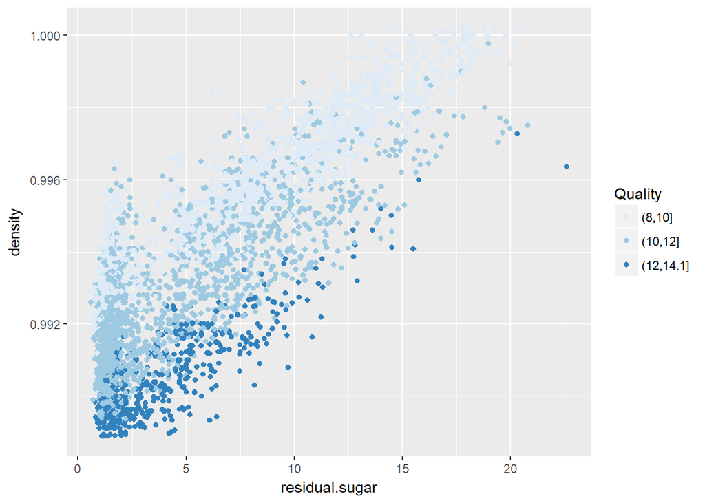

Highly dense wines have less alcohol and more sweetness. Wines with higher alcohol contents have less density and sweetness.

# Density vs Total sulfur dioxide vs alcohol

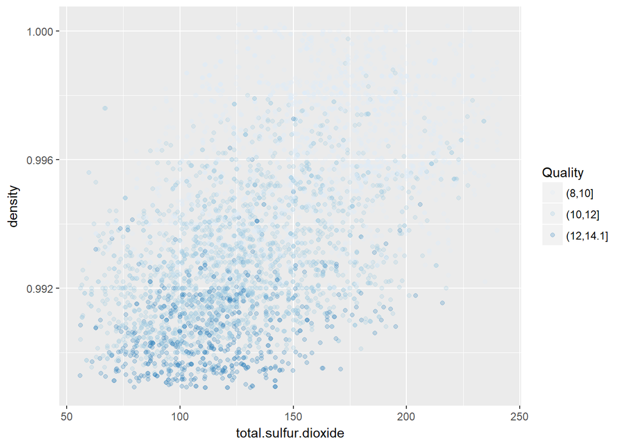

# Fitting a linear model

```
##
## Call:
## lm(formula = quality ~ ., data = white)
##
## Residuals:
##     Min      1Q  Median      3Q     Max
## -3.4966 -0.4938 -0.0404  0.4386  3.0359
##
## Coefficients:
##                        Estimate Std. Error t value Pr(>|t|)
## (Intercept)           2.332e+02  2.541e+01   9.177  < 2e-16 ***
## X                    -6.913e-05  8.773e-06  -7.881 4.08e-15 ***
## fixed.acidity         1.121e-01  2.650e-02   4.231 2.37e-05 ***
## volatile.acidity     -1.941e+00  1.372e-01 -14.146  < 2e-16 ***
## citric.acid          -1.485e-01  1.008e-01  -1.472  0.14098
## residual.sugar        1.075e-01  9.500e-03  11.315  < 2e-16 ***
## chlorides            -2.876e-01  8.485e-01  -0.339  0.73469
## free.sulfur.dioxide   4.759e-03  9.090e-04   5.236 1.72e-07 ***
## total.sulfur.dioxide -4.009e-04  4.238e-04  -0.946  0.34417
## density              -2.328e+02  2.574e+01  -9.045  < 2e-16 ***
## pH                    7.578e-01  1.231e-01   6.155 8.17e-10 ***
## sulphates             7.710e-01  1.068e-01   7.218 6.18e-13 ***
## alcohol               4.645e-02  3.963e-02   1.172  0.24126
## alc_buckets(10,12]    6.635e-02  4.554e-02   1.457  0.14521
## alc_buckets(12,14.1]  2.588e-01  8.513e-02   3.040  0.00238 **
## ---
## Signif. codes:  0 '***' 0.001 '**' 0.01 '*' 0.05 '.' 0.1 ' ' 1
##
## Residual standard error: 0.7319 on 4362 degrees of freedom
## Multiple R-squared:  0.2855, Adjusted R-squared:  0.2832
## F-statistic: 124.5 on 14 and 4362 DF,  p-value: < 2.2e-16
```

# Multivariate Analysis

Talk about some of the relationships you observed in this part of the investigation. Were there features that strengthened each other in terms of looking at your feature(s) of interest?

The relationships which I observed were

1)Alcohol,density and quality : As alcohol increases density decreases,the wine following this trend gets a better rating,i.e a poorly rated wine has low alcohol content and high density.

2)Density,Sugar,Alcohol : Highly dense wines have less alcohol and more sweetness.Wines with higher alcohol contents have less density and sweetness.

Were there any interesting or surprising interactions between features?

A surprising interaction was that though the correlation between alcohol and quality is less it has significant effect on the rating as seen from exploratory data analysis.

# Final Plots and Summary

# Plot One

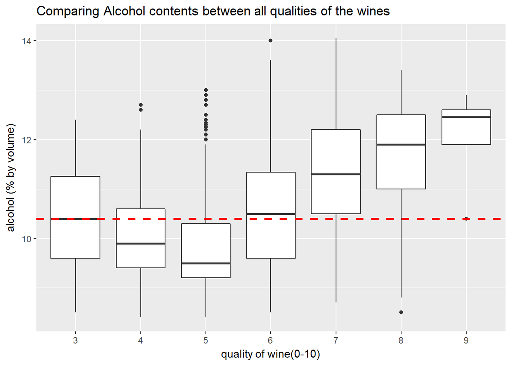

# Description One

# Plot Two

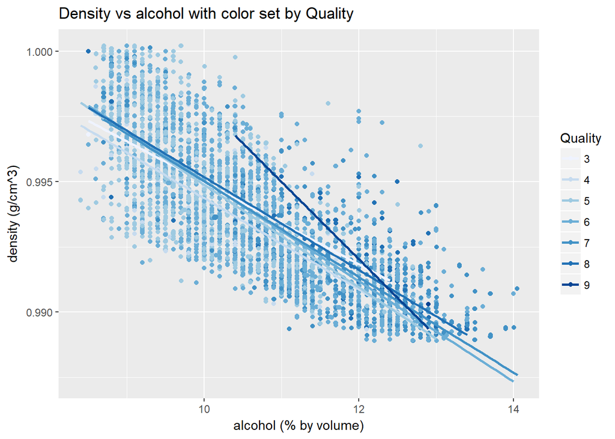

# Description Two

This plot is a good visualisation to see the influence of alcohol and density on the quality of wine. I can see from the plots that there is a cluster of points concentrated in different parts of the graph for each quality.The cluster eventually moves from top left to bottom right.From this I can infer that as alcohol content increased and density became lesser,the quality of the wine increased. The cluster is less dense for the higher qualities as there are only a few data points which are rated high. The plot shows a trend which cannot be clearly seen from correlations due to less datapoints of wines with higher ratings.Exploratory Data Analysis helped uncover this trend.

# Plot Three

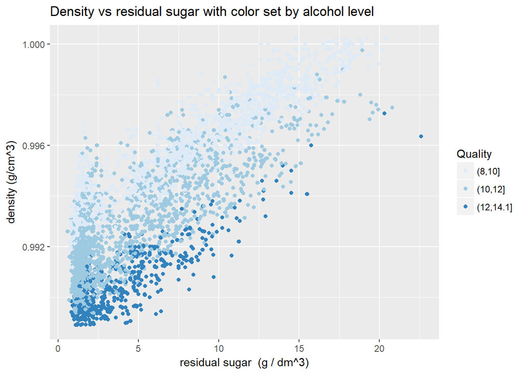

# Description Three

This plot is a clear visualisation of the correlation between density,residual sugar and alcohol level.From the plot there are clearly different clusters as we can observe from different shades.The dark patch at the bottom left are all the wines with low density and residual sugars,all wines with high alcohol content fall in this region.The lighter region consists of wines with medium alcohol levels,the density and sugar levels are also moderate.The lightest patch consists of all the wines with low alcohol content and high density and residual sugar values. From my study of wine preparation,the residual sugar is the sugar left in the wine after fermentation.This plot is interesting as it tells us that wines with low alcohol are sweeter than wines with high alcohol levels.Also that less denser wines are going to taste bitter.

# Reflection

EDA helped me to have insight into trends and patterns hidden in the data. The wine dataset has no null values. First look into the data, I observed that all the wines were rated between 3 and 9 though the scale is from 1 to 10.

I plotted histograms to understand the distribution of the data. Histograms for most variables showed normal distributions with a few bimodal distributions and long tailed distributions. A few outliers were clearly visible and made me realise that this was reason for long tail and bimodal distribution.I eliminated the outliers, the datapoints above the 99th percentile and below 1st percentile were removed.Then histograms appear normally distributed for almost all variables.

I then looked at correlations between variables.The ggally package serves as an excellent package to generate scatterplot of correlations between all the variables.The scatterplot also showed correlation values.I noted the pairs with high correlation values and plotted them to get a better understanding of the trends,I was able to draw smoothing lines using geom_smooth which captured the trend clearly.

I was also interested in the effects of different variables on the quality.I plotted all the variables-quality pairs along with their boxplots to see their relationship.I compared the medians across all qualities with the over all median of the data related to each attribute.I could find distinct trends between attributes and quality.

Multivariate analysis was challenging as it was not easy to see trends with the original data so I restructured data by putting a few variables into different classes.The trends were clearly visible after reshaping,it also gave me more insight into wine preparation processes. The other challenge I faced was the inavaialability of data corresponding to higher and lower qualities of wine.There might be more trends and patterns which I cannot discern with the present data set.

My analysis only dealt with highly correlated attributes,there could be trends and patterns hidden within uncorrelated attributes and also effects of certain attributes on quality could be much more than expected.This inference is supported by a few attributes getting surprisingly heavier weights on the linear model developed.